# SR_01_DISREG_ENTITY_ADDR_L1

Disregarded entity street address line 1 · Text report

## Overview

**Description**

Address Foreign - AddressLine1

**Table**

`SR-P01-T01-ID-DISREGARDED-ENTITIES` (many)

**Location code**

`SCHED-R-PART-01-COL-A`

**Family**

`SCHED-R-PART-01-COL-A` · siblings: SR_01_DISREG_ENTITY_ADDR_CITY, SR_01_DISREG_ENTITY_ADDR_CNTR, SR_01_DISREG_ENTITY_ADDR_L2, SR_01_DISREG_ENTITY_ADDR_STATE, SR_01_DISREG_ENTITY_ADDR_ZIP, SR_01_DISREG_ENTITY_EIN

**Data type**

text (xsd: StreetAddressType)

**Scope**

PC

**Status**

unreviewed

6

xpaths mapped (6 observed)

117,575

filings with a value

2009–2024

tax years observed

4

open flags (1 errors)

## Flags

| Severity | Flag | Xpath | Detail |
| --- | --- | --- | --- |
| ⚠ error | `COLLISION` | IRS990ScheduleR/IdDisregardedEntitiesGrp/ForeignAddress/AddressLine1Txt | 840 filings contain 2+ of its xpaths; most common set: /Return/ReturnData/IRS990ScheduleR/IdDisregardedEntitiesGrp/ForeignAddress/AddressLine1Txt ; /Return/ReturnData/IRS990ScheduleR/IdDisregardedEnti… |
| ⓘ info | `MANY_NOT_REPEATING` | IRS990ScheduleR/IdDisregardedEntitiesGrp/USAddress/AddressLine1Txt | many-to-one table, but 58% of values sit in no repeating element |
| ⓘ info | `MANY_NOT_REPEATING` | IRS990ScheduleR/Form990ScheduleRPartI/AddressUS/AddressLine1 | many-to-one table, but 58% of values sit in no repeating element |
| ⓘ info | `MANY_NOT_REPEATING` | IRS990ScheduleR/IdDisregardedEntitiesGrp/USAddress/AddressLine1 | many-to-one table, but 58% of values sit in no repeating element |

## Xpaths

All mapped xpaths (under /Return/ReturnData or /Return/ReturnHeader), oldest first. Charts label each series by its xpath.

| Xpath | Form | Chart label | First year | Last year | Versions | Filings | Repeats in |
| --- | --- | --- | --- | --- | --- | --- | --- |
| IRS990ScheduleR/Form990ScheduleRPartI/AddressUS/AddressLine1 | Sched R | same | 2009 | 2012 | 17 | 15,198 | 41.7% |
| IRS990ScheduleR/Form990ScheduleRPartI/AddressForeign/AddressLine1 | Sched R | …heduleR/Form990ScheduleRPartI/AddressForeign/AddressLine1 | 2009 | 2012 | 15 | 300 | 22.7% |
| IRS990ScheduleR/IdDisregardedEntitiesGrp/USAddress/AddressLine1 | Sched R | …ScheduleR/IdDisregardedEntitiesGrp/USAddress/AddressLine1 | 2013 | 2013 | 3 | 5,674 | 41.6% |
| IRS990ScheduleR/IdDisregardedEntitiesGrp/ForeignAddress/AddressLine1 | Sched R | …uleR/IdDisregardedEntitiesGrp/ForeignAddress/AddressLine1 | 2013 | 2013 | 3 | 116 | 28.4% |
| IRS990ScheduleR/IdDisregardedEntitiesGrp/USAddress/AddressLine1Txt | Sched R | …eduleR/IdDisregardedEntitiesGrp/USAddress/AddressLine1Txt | 2014 | 2024 | 34 | 94,365 | 41.7% |
| IRS990ScheduleR/IdDisregardedEntitiesGrp/ForeignAddress/AddressLine1Txt | Sched R | …R/IdDisregardedEntitiesGrp/ForeignAddress/AddressLine1Txt | 2014 | 2024 | 33 | 1,922 | 36.7% |

## Coverage

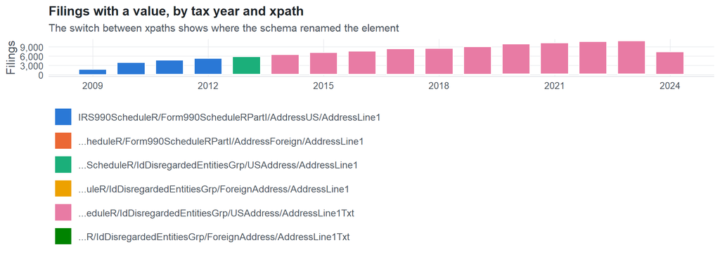

**Table view**

Table view: filings by tax year and series

| Tax year | IRS990ScheduleR/Form990ScheduleRPartI/AddressUS/AddressLine1 | …heduleR/Form990ScheduleRPartI/AddressForeign/AddressLine1 | …ScheduleR/IdDisregardedEntitiesGrp/USAddress/AddressLine1 | …uleR/IdDisregardedEntitiesGrp/ForeignAddress/AddressLine1 | …eduleR/IdDisregardedEntitiesGrp/USAddress/AddressLine1Txt | …R/IdDisregardedEntitiesGrp/ForeignAddress/AddressLine1Txt |
| --- | --- | --- | --- | --- | --- | --- |
| 2009 | 1,642 | 44 | 0 | 0 | 0 | 0 |
| 2010 | 3,830 | 78 | 0 | 0 | 0 | 0 |
| 2011 | 4,569 | 86 | 0 | 0 | 0 | 0 |
| 2012 | 5,157 | 92 | 0 | 0 | 0 | 0 |
| 2013 | 0 | 0 | 5,674 | 116 | 0 | 0 |
| 2014 | 0 | 0 | 0 | 0 | 6,371 | 121 |
| 2015 | 0 | 0 | 0 | 0 | 6,972 | 132 |
| 2016 | 0 | 0 | 0 | 0 | 7,455 | 141 |
| 2017 | 0 | 0 | 0 | 0 | 8,214 | 148 |
| 2018 | 0 | 0 | 0 | 0 | 8,351 | 159 |
| 2019 | 0 | 0 | 0 | 0 | 8,893 | 176 |
| 2020 | 0 | 0 | 0 | 0 | 9,670 | 203 |
| 2021 | 0 | 0 | 0 | 0 | 10,045 | 213 |
| 2022 | 0 | 0 | 0 | 0 | 10,486 | 226 |
| 2023 | 0 | 0 | 0 | 0 | 10,704 | 235 |
| 2024 | 0 | 0 | 0 | 0 | 7,204 | 168 |

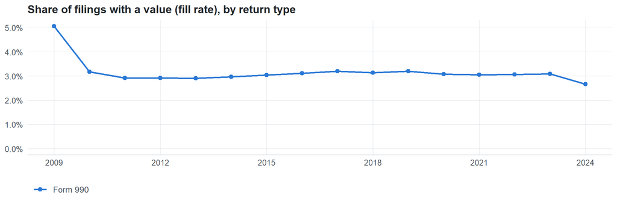

**Table view**

Table view: fill rate

| Tax year | Return type | Filings | All filings | Fill rate |
| --- | --- | --- | --- | --- |
| 2009 | Form 990 | 1,686 | 33,311 | 5.06% |
| 2010 | Form 990 | 3,908 | 123,025 | 3.18% |
| 2011 | Form 990 | 4,655 | 159,504 | 2.92% |
| 2012 | Form 990 | 5,249 | 179,688 | 2.92% |
| 2013 | Form 990 | 5,790 | 198,855 | 2.91% |
| 2014 | Form 990 | 6,492 | 218,619 | 2.97% |
| 2015 | Form 990 | 7,104 | 233,519 | 3.04% |
| 2016 | Form 990 | 7,596 | 243,903 | 3.11% |
| 2017 | Form 990 | 8,362 | 261,612 | 3.20% |
| 2018 | Form 990 | 8,510 | 271,442 | 3.14% |
| 2019 | Form 990 | 9,069 | 283,694 | 3.20% |
| 2020 | Form 990 | 9,873 | 320,342 | 3.08% |
| 2021 | Form 990 | 10,258 | 336,480 | 3.05% |
| 2022 | Form 990 | 10,712 | 349,055 | 3.07% |
| 2023 | Form 990 | 10,939 | 354,768 | 3.08% |
| 2024 | Form 990 | 7,372 | 277,298 | 2.66% |

## Repeating groups

Table cardinality in the concordance: **many**. 6 of 6 observed xpaths repeat within a filing.

Repeating element each xpath was observed in (from the raw indexed xpath)

| Xpath | Repeating element | Filings (summed over years) |
| --- | --- | --- |
| IRS990ScheduleR/Form990ScheduleRPartI/AddressForeign/AddressLine1 | (none) | 127 |
| IRS990ScheduleR/Form990ScheduleRPartI/AddressForeign/AddressLine1 | IRS990ScheduleR/Form990ScheduleRPartI | 173 |
| IRS990ScheduleR/Form990ScheduleRPartI/AddressUS/AddressLine1 | (none) | 8811 |
| IRS990ScheduleR/Form990ScheduleRPartI/AddressUS/AddressLine1 | IRS990ScheduleR/Form990ScheduleRPartI | 6387 |
| IRS990ScheduleR/IdDisregardedEntitiesGrp/ForeignAddress/AddressLine1 | (none) | 43 |
| IRS990ScheduleR/IdDisregardedEntitiesGrp/ForeignAddress/AddressLine1 | IRS990ScheduleR/IdDisregardedEntitiesGrp | 73 |
| IRS990ScheduleR/IdDisregardedEntitiesGrp/USAddress/AddressLine1 | (none) | 3283 |
| IRS990ScheduleR/IdDisregardedEntitiesGrp/USAddress/AddressLine1 | IRS990ScheduleR/IdDisregardedEntitiesGrp | 2391 |
| IRS990ScheduleR/IdDisregardedEntitiesGrp/ForeignAddress/AddressLine1Txt | (none) | 848 |
| IRS990ScheduleR/IdDisregardedEntitiesGrp/ForeignAddress/AddressLine1Txt | IRS990ScheduleR/IdDisregardedEntitiesGrp | 1074 |
| IRS990ScheduleR/IdDisregardedEntitiesGrp/USAddress/AddressLine1Txt | (none) | 54639 |
| IRS990ScheduleR/IdDisregardedEntitiesGrp/USAddress/AddressLine1Txt | IRS990ScheduleR/IdDisregardedEntitiesGrp | 39726 |

## Values

[output not shown]

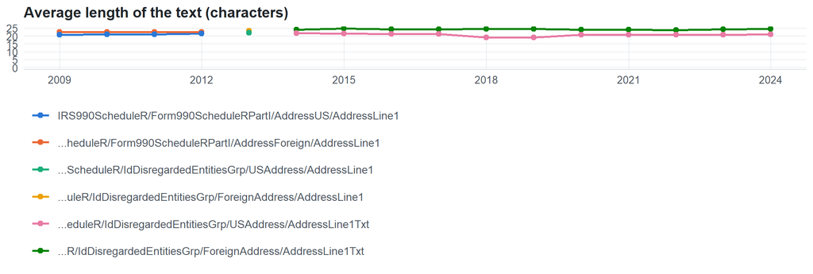

**Table view**

Table view: length and variety by tax year

| Series | Tax year | Filings | Avg length | Max length | Distinct values (approx.) |
| --- | --- | --- | --- | --- | --- |
| IRS990ScheduleR/Form990ScheduleRPartI/AddressUS/AddressLine1 | 2009 | 1,642 | 21 | 35 | 1,649 |
| IRS990ScheduleR/Form990ScheduleRPartI/AddressUS/AddressLine1 | 2010 | 3,830 | 21 | 35 | 2,109 |
| IRS990ScheduleR/Form990ScheduleRPartI/AddressUS/AddressLine1 | 2011 | 4,569 | 21 | 35 | 2,648 |
| IRS990ScheduleR/Form990ScheduleRPartI/AddressUS/AddressLine1 | 2012 | 5,157 | 21 | 35 | 3,380 |
| …heduleR/Form990ScheduleRPartI/AddressForeign/AddressLine1 | 2009 | 44 | 22 | 35 | 46 |
| …heduleR/Form990ScheduleRPartI/AddressForeign/AddressLine1 | 2010 | 78 | 23 | 35 | 77 |
| …heduleR/Form990ScheduleRPartI/AddressForeign/AddressLine1 | 2011 | 86 | 23 | 35 | 79 |
| …heduleR/Form990ScheduleRPartI/AddressForeign/AddressLine1 | 2012 | 92 | 23 | 35 | 98 |
| …ScheduleR/IdDisregardedEntitiesGrp/USAddress/AddressLine1 | 2013 | 5,674 | 22 | 35 | 2,678 |
| …uleR/IdDisregardedEntitiesGrp/ForeignAddress/AddressLine1 | 2013 | 116 | 23 | 35 | 85 |
| …eduleR/IdDisregardedEntitiesGrp/USAddress/AddressLine1Txt | 2014 | 6,371 | 22 | 35 | 3,527 |
| …eduleR/IdDisregardedEntitiesGrp/USAddress/AddressLine1Txt | 2015 | 6,972 | 21 | 35 | 3,687 |
| …eduleR/IdDisregardedEntitiesGrp/USAddress/AddressLine1Txt | 2016 | 7,455 | 21 | 35 | 7,554 |
| …eduleR/IdDisregardedEntitiesGrp/USAddress/AddressLine1Txt | 2017 | 8,214 | 21 | 35 | 6,725 |
| …eduleR/IdDisregardedEntitiesGrp/USAddress/AddressLine1Txt | 2018 | 8,351 | 19 | 35 | 8,169 |
| …eduleR/IdDisregardedEntitiesGrp/USAddress/AddressLine1Txt | 2019 | 8,893 | 19 | 35 | 5,469 |
| …eduleR/IdDisregardedEntitiesGrp/USAddress/AddressLine1Txt | 2020 | 9,670 | 21 | 35 | 4,524 |
| …eduleR/IdDisregardedEntitiesGrp/USAddress/AddressLine1Txt | 2021 | 10,045 | 21 | 35 | 10,476 |
| …eduleR/IdDisregardedEntitiesGrp/USAddress/AddressLine1Txt | 2022 | 10,486 | 21 | 35 | 10,106 |
| …eduleR/IdDisregardedEntitiesGrp/USAddress/AddressLine1Txt | 2023 | 10,704 | 21 | 35 | 6,408 |
| …eduleR/IdDisregardedEntitiesGrp/USAddress/AddressLine1Txt | 2024 | 7,204 | 21 | 35 | 5,013 |
| …R/IdDisregardedEntitiesGrp/ForeignAddress/AddressLine1Txt | 2014 | 121 | 24 | 35 | 113 |
| …R/IdDisregardedEntitiesGrp/ForeignAddress/AddressLine1Txt | 2015 | 132 | 25 | 35 | 139 |
| …R/IdDisregardedEntitiesGrp/ForeignAddress/AddressLine1Txt | 2016 | 141 | 24 | 35 | 227 |
| …R/IdDisregardedEntitiesGrp/ForeignAddress/AddressLine1Txt | 2017 | 148 | 24 | 35 | 184 |
| …R/IdDisregardedEntitiesGrp/ForeignAddress/AddressLine1Txt | 2018 | 159 | 24 | 35 | 204 |
| …R/IdDisregardedEntitiesGrp/ForeignAddress/AddressLine1Txt | 2019 | 176 | 25 | 35 | 219 |
| …R/IdDisregardedEntitiesGrp/ForeignAddress/AddressLine1Txt | 2020 | 203 | 24 | 35 | 186 |
| …R/IdDisregardedEntitiesGrp/ForeignAddress/AddressLine1Txt | 2021 | 213 | 24 | 35 | 388 |
| …R/IdDisregardedEntitiesGrp/ForeignAddress/AddressLine1Txt | 2022 | 226 | 24 | 35 | 427 |
| …R/IdDisregardedEntitiesGrp/ForeignAddress/AddressLine1Txt | 2023 | 235 | 24 | 35 | 281 |
| …R/IdDisregardedEntitiesGrp/ForeignAddress/AddressLine1Txt | 2024 | 168 | 24 | 35 | 186 |

Most common values by xpath (all years; long values truncated)

| Series | Value | Filings | Share |
| --- | --- | --- | --- |
| IRS990ScheduleR/Form990ScheduleRPartI/AddressUS/AddressLine1 | 1660 DUKE STREET | 413 | 2.7% |
| IRS990ScheduleR/Form990ScheduleRPartI/AddressUS/AddressLine1 | 1660 Duke Street | 171 | 1.1% |
| IRS990ScheduleR/Form990ScheduleRPartI/AddressUS/AddressLine1 | 345 SPEAR STREET SUITE 700 | 139 | 0.9% |
| IRS990ScheduleR/Form990ScheduleRPartI/AddressUS/AddressLine1 | 8425 E TWELVE MILE ROAD | 129 | 0.8% |
| IRS990ScheduleR/Form990ScheduleRPartI/AddressUS/AddressLine1 | 303 VINTAGE PARK DRIVE SUITE 250 | 129 | 0.8% |
| IRS990ScheduleR/Form990ScheduleRPartI/AddressUS/AddressLine1 | 1300 Massachusetts Avenue | 115 | 0.8% |
| IRS990ScheduleR/Form990ScheduleRPartI/AddressUS/AddressLine1 | 5400 E OLYMPIC BLVD STE 300 | 93 | 0.6% |
| IRS990ScheduleR/Form990ScheduleRPartI/AddressUS/AddressLine1 | 10 West Broad St Ste 2100 | 55 | 0.4% |
| IRS990ScheduleR/Form990ScheduleRPartI/AddressUS/AddressLine1 | 1050 SW 3RD AVE SUITE 1600 | 55 | 0.4% |
| IRS990ScheduleR/Form990ScheduleRPartI/AddressUS/AddressLine1 | 120 W HARRIS ST | 55 | 0.4% |
| IRS990ScheduleR/Form990ScheduleRPartI/AddressUS/AddressLine1 | 17410 COLLEGE PARKWAY STE 150 | 55 | 0.4% |
| IRS990ScheduleR/Form990ScheduleRPartI/AddressUS/AddressLine1 | 200 JEFFERSON AVE SE | 55 | 0.4% |
| IRS990ScheduleR/Form990ScheduleRPartI/AddressUS/AddressLine1 | 34605 W TWELVE MILE ROAD | 55 | 0.4% |
| IRS990ScheduleR/Form990ScheduleRPartI/AddressUS/AddressLine1 | 6150 E BROAD STREET | 55 | 0.4% |
| IRS990ScheduleR/Form990ScheduleRPartI/AddressUS/AddressLine1 | 5901 MONCLOVA RD | 29 | 0.2% |
| IRS990ScheduleR/Form990ScheduleRPartI/AddressUS/AddressLine1 | 5855 MONROE ST | 28 | 0.2% |
| IRS990ScheduleR/Form990ScheduleRPartI/AddressUS/AddressLine1 | 901 KIMOLE LN | 28 | 0.2% |
| IRS990ScheduleR/Form990ScheduleRPartI/AddressUS/AddressLine1 | 4800 E JOHNSON AVE | 27 | 0.2% |
| IRS990ScheduleR/Form990ScheduleRPartI/AddressUS/AddressLine1 | 3070 NORTH 51ST STREET STE 406 | 23 | 0.2% |
| IRS990ScheduleR/Form990ScheduleRPartI/AddressUS/AddressLine1 | 3421 WEST NINTH STREET | 22 | 0.1% |
| IRS990ScheduleR/Form990ScheduleRPartI/AddressUS/AddressLine1 | 3024 STADIUM BLVD | 22 | 0.1% |
| IRS990ScheduleR/Form990ScheduleRPartI/AddressUS/AddressLine1 | 10330 N Meridian Ste 300 | 22 | 0.1% |
| IRS990ScheduleR/Form990ScheduleRPartI/AddressUS/AddressLine1 | 10330 N Meridian Ste 430N | 22 | 0.1% |
| IRS990ScheduleR/Form990ScheduleRPartI/AddressUS/AddressLine1 | 1907 W Sycamore Street | 22 | 0.1% |
| IRS990ScheduleR/Form990ScheduleRPartI/AddressUS/AddressLine1 | 8425 Harcourt Road | 22 | 0.1% |
| IRS990ScheduleR/Form990ScheduleRPartI/AddressUS/AddressLine1 | 1801 RICHARDS RD | 21 | 0.1% |
| IRS990ScheduleR/Form990ScheduleRPartI/AddressUS/AddressLine1 | 2142 NORTH COVE | 21 | 0.1% |
| …heduleR/Form990ScheduleRPartI/AddressForeign/AddressLine1 | 23 Lime Tree Bay Ave Box 1051 | 9 | 3.0% |
| …heduleR/Form990ScheduleRPartI/AddressForeign/AddressLine1 | FB Perry Building 40 Church Street | 6 | 2.0% |
| …heduleR/Form990ScheduleRPartI/AddressForeign/AddressLine1 | PO Box 1051 | 6 | 2.0% |

First rows shown.

## Examples

| Tax year | Return | Xpath | Organization | Value | Source |
| --- | --- | --- | --- | --- | --- |
| 2024 | 990 | IRS990ScheduleR/IdDisregardedEntitiesGrp/ForeignAddress/AddressLine1Txt | NRECA INTERNATIONAL | 401 OM CITRA BLDG 39 | [XML](https://gt990datalake-rawdata.s3.amazonaws.com/EfileData/XmlFiles/202513219349325546_public.xml) |
| 2024 | 990 | IRS990ScheduleR/IdDisregardedEntitiesGrp/USAddress/AddressLine1Txt | RISEWELL COMMUNITY SERVICES INC FKA | 1 FARMINGDALE ROAD- ROUTE 109 | [XML](https://gt990datalake-rawdata.s3.amazonaws.com/EfileData/XmlFiles/202610589349301811_public.xml) |
| 2023 | 990 | IRS990ScheduleR/IdDisregardedEntitiesGrp/ForeignAddress/AddressLine1Txt | BAYADA HOME HEALTH CARE INC | WEYERSTR 252 | [XML](https://gt990datalake-rawdata.s3.amazonaws.com/EfileData/XmlFiles/202433209349325168_public.xml) |
| 2023 | 990 | IRS990ScheduleR/IdDisregardedEntitiesGrp/USAddress/AddressLine1Txt | ARH TUG VALLEY HEALTH SERVICES INC | 2260 EXECUTIVE DRIVE | [XML](https://gt990datalake-rawdata.s3.amazonaws.com/EfileData/XmlFiles/202511349349306946_public.xml) |
| 2022 | 990 | IRS990ScheduleR/IdDisregardedEntitiesGrp/ForeignAddress/AddressLine1Txt | THE NATURE CONSERVANCY | 10 QUEEN STREET PLACE | [XML](https://gt990datalake-rawdata.s3.amazonaws.com/EfileData/XmlFiles/202431279349301813_public.xml) |
| 2022 | 990 | IRS990ScheduleR/IdDisregardedEntitiesGrp/USAddress/AddressLine1Txt | SUN MINISTRIES INC | 1515 Newhouse Ave | [XML](https://gt990datalake-rawdata.s3.amazonaws.com/EfileData/XmlFiles/202313199349304366_public.xml) |
| 2021 | 990 | IRS990ScheduleR/IdDisregardedEntitiesGrp/ForeignAddress/AddressLine1Txt | GLOBAL NOMADS GROUP INC | 41 AL-SHAREAA ST ALWEIBDAH | [XML](https://gt990datalake-rawdata.s3.amazonaws.com/EfileData/XmlFiles/202301329349306965_public.xml) |
| 2021 | 990 | IRS990ScheduleR/IdDisregardedEntitiesGrp/USAddress/AddressLine1Txt | VIRGINIA BEACH PUBLIC SCHOOLS | 641 CARRAGE HILL DR | [XML](https://gt990datalake-rawdata.s3.amazonaws.com/EfileData/XmlFiles/202310839349300011_public.xml) |
| 2020 | 990 | IRS990ScheduleR/IdDisregardedEntitiesGrp/ForeignAddress/AddressLine1Txt | ST JOHN’S UNIVERSITY NEW YORK | 93 RUE DE SEVRES | [XML](https://gt990datalake-rawdata.s3.amazonaws.com/EfileData/XmlFiles/202230989349301408_public.xml) |
| 2020 | 990 | IRS990ScheduleR/IdDisregardedEntitiesGrp/USAddress/AddressLine1Txt | ORLANDO REGIONAL REALTOR ASSOCIATION | 1330 LEE ROAD | [XML](https://gt990datalake-rawdata.s3.amazonaws.com/EfileData/XmlFiles/202113199349304396_public.xml) |
| 2019 | 990 | IRS990ScheduleR/IdDisregardedEntitiesGrp/ForeignAddress/AddressLine1Txt | UNITED STATES SOYBEAN EXPORT COUNCIL | GUADALAJARA WORLD TRADE CENTER AVE | [XML](https://gt990datalake-rawdata.s3.amazonaws.com/EfileData/XmlFiles/202132249349301703_public.xml) |
| 2019 | 990 | IRS990ScheduleR/IdDisregardedEntitiesGrp/USAddress/AddressLine1Txt | OTSEGO ELECTRIC COOPERATIVE INC | PO BOX 128 | [XML](https://gt990datalake-rawdata.s3.amazonaws.com/EfileData/XmlFiles/202042809349300629_public.xml) |

## Reviewer checklist

- The definition matches the form line and instructions for every xpath’s schema years.
- Every xpath pooled here measures the same thing on the 990 and 990-EZ (close enough for analysis).
- The coverage chart has no unexplained gaps or jumps between tax years.
- Each open flag is fixed, or accepted with a note in validation_log.csv.
- Values answer the question on the form line (not another line’s explanation).
- Boilerplate such as ‘See Schedule O’ or ‘N/A’ is expected here, or should be treated as missing.
- Text that is really a number or a code is flagged for a different data type.

Record the review as a row in `inst/extdata/src/validation_log.csv` (variable_name, reviewer, date, status, note). Evidence built 2026-09-23 17:09:04 MST from the ef2 DuckDB builds (tax years 2009–2024).